# problem solving with data

gaurav sood

# Power Tools

## Think About Numbers

## Law of Large Numbers

- Life before Big Query
- How did we know?

[figure not shown]

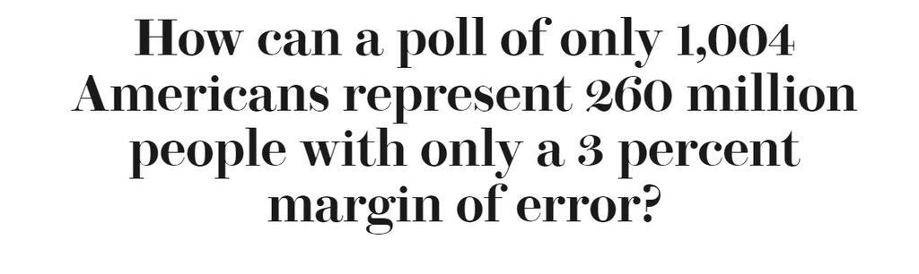

## Magic

- Random sample
  - 100 people
  - another 100 people
  - their means will generally differ because of sampling variation
  - how about 1000 people?
  - less different
  - for independent Bernoulli samples, the sample proportion has standard deviation
    - $\sqrt \frac{p*(1 -p)}{n}$
    - maximize this given $n$
    - also called the standard error; a normal approximation needs enough expected successes and failures

[Video example](https://www.youtube.com/watch?v=Kq7e6cj2nDw)

## MECE

- Management consultants swear by it, so it can’t be a good idea. Right?
- Mutually Exclusive, Collectively Exhaustive
- Sample Failures
  - Assign ‘type’ of failure

## Doordash

- Say that they are having trouble giving good ETAs
  - Pre-pickup
    - cooking times
  - Post-pickup
    - 5 miles
      - average error +/- 30 minutes
        - when you have good location data
          - your estimates are still bad
          - under good conditions, how often do you fail?
            - dasher is close
            - dasher has good location data
            - what’s the excuse?

## Systemic Thinking

- Sources of the problem
  - Meta failure
  - Localized failure
    - Browser
    - OS

## Exploit the Skew

- There would be no startups if:
  - each problem = lots of small ROI issues
- Pareto distribution
  - 80–20 rule
  - For a Pareto model, $P(X>x_2\mid X>x_1)=(x_1/x_2)^\alpha$ for $x_2\geq x_1\geq x_{\min}$
  - Under an exact Pareto income model with finite mean, a top-20% share of 80% implies a top-4% share of 64%. The first share alone does not imply the second without the distributional assumption.
  - At nearly each stage of problem solving, asymmetric returns

## Dr. House

- Differential Diagnosis
- Do something
  - If it fixes things…